# External sector

Session 2

Luis F. Gómez L.

luis.gomezl@unimilitar.edu.co

Distance Learning Faculty

5 February, 2026

# Please Read Me

- Check the message **Welcome greeting** published in Announcements forum.
- Dear student please edit your profile uploading a photo where your face is clearly visible.
- If you want to participate, please fill out the following survey: **Primer corte 30% > Learning Activities > Tu opinión sobre la economía colombiana**
- This presentation is based on (Cardenas, 2020, Chapter 5)
- **Purpose**
  - Explain the composition and determinants of Colombian foreign trade

# The concept of comparative advantage

- **Absolute advantage**: the ability of a party (individual, company, country) to produce a product more efficiently than any other party
  - A party should concentrate in producing a good in which it has an absolute advantage
  - ¿What happend when you don’t have an absolute advantage?
- **Comparative advantage**: the ability of a party (individual, company, country) to produce a product at a lower relative opportunity cost
  - Under certain conditions, even if a party doesn’t have an **absolute advantage**, trade with other agent can be benefical for both of them
- Example of gains of trade using the concept of **comparative advantage** (Ridley, 2010)
  - **Agent 1** produce 1 spear in 4 hours and 1 axe in 3 hours.
    - To produce both products **agent 1** will need to allocate 7 hours
  - **Agent 2** produce 1 spear in 1 hour and 1 axe in 2 hours.
    - **Agent 2** has the absolute advantage in the prodution of spears and axes.
    - To produce both products **agent 2** will need to allocate 3 hours
  - ¿It will be benefical for agent 1 and 2 to trade? Yes!!! **Agent 1** can produce 2 axes in 6 hours and **agent 2** 2 spears in 2 hours. Then they can trade 1 spear for 1 axe.
    - **Agent 1** has now 1 spear and 1 axe only working 6 hours.
    - Furthermore **agent 2** has now 1 spear and 1 axe only working 2 hours.
    - Each of them saves 1 hour of work in contrast with a situation in which they don’t trade and produce themselves both products.

# International trade: goods

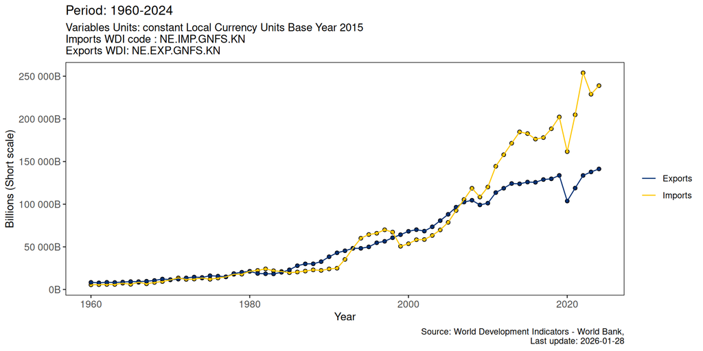

Figure 1: Colombia imports and exports

- The **Harmonized System (HS)** is a standardized numerical method of classifying traded goods that is internationally accepted and maintained by the **World Customs Organization (WCO)**
- The HS code consists of 6-digits that are the same independent of the country:
  - First 2 digits designate the **HS** chapter
  - Second 2 digits designate the **HS** heading
  - Third 2 digits designate the **HS** subheading
- Example of **HS** code: 090111 (Coffee, not roasted, not decaffeinated)
  - Chapter **09**: Cofee, tea, mate and spices
  - Heading **01**: Coffee, whether or not roasted or decaffeinated; coffee husks and skins; coffee substitutes containing coffee in any proportion
  - Subheading **11**: Coffee, not roasted, not decaffeinated

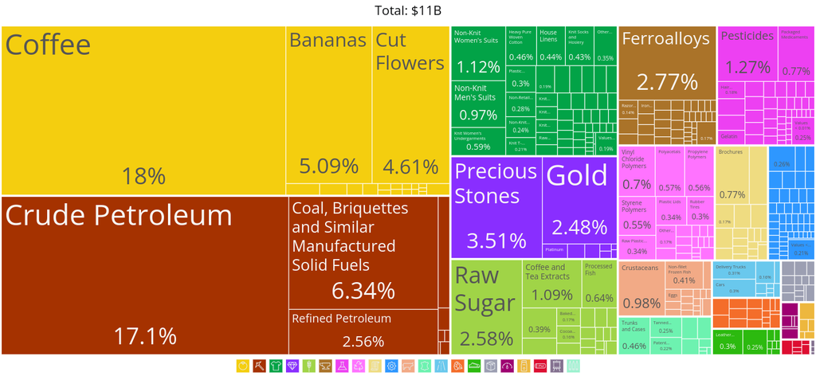

Figure 2: Colombian good exports **HS 4 digits (HS92) edition** year 1995 (Simoes & Hidalgo, 2011)

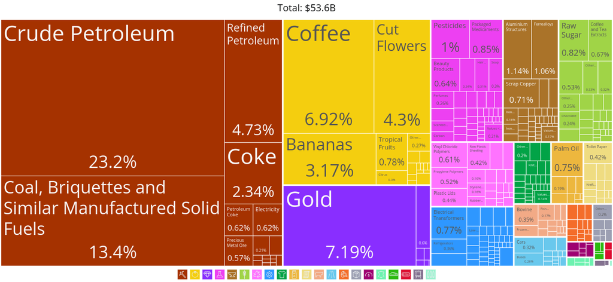

Figure 3: Colombian good exports **HS 4 digits (HS92) edition** year 2024 (Simoes & Hidalgo, 2011)

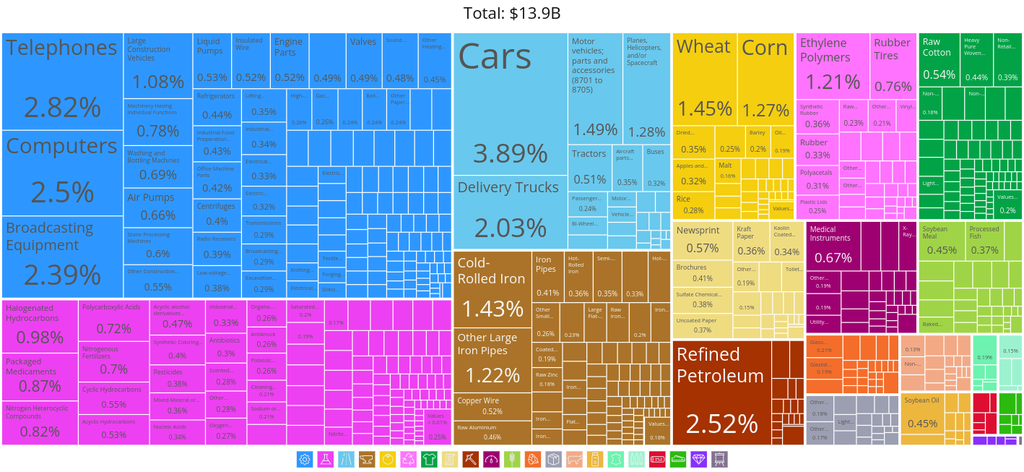

Figure 4: Colombian goods imports **HS 4 digits (HS92) edition** year 1995 (Simoes & Hidalgo, 2011)

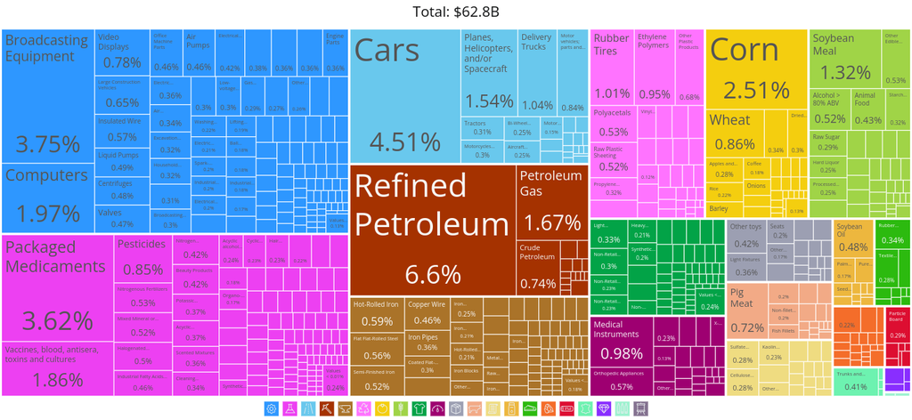

Figure 5: Colombian goods imports **HS 4 digits (HS92) edition** year 2024 (Simoes & Hidalgo, 2011)

# International trade: services

- The Extended Balance of Payments Services Classification (EBOPS) provides a breakdown of the Balance of Payments Trade in Services by types of services.
- The classification thereby meets a number of user requirements, including the provision of more detailed information on Trade in services
  - **EBOPS 2002**
  - **EBOPS 2010**
- For more information check out
  - (Nationen & Kommission, 2002)
  - (Nations, 2012)

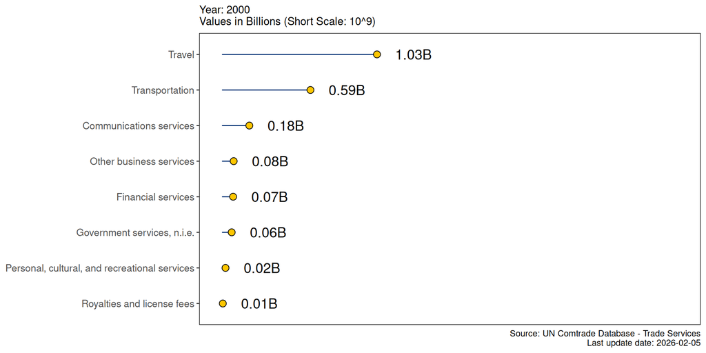

Figure 6: Colombia service exports

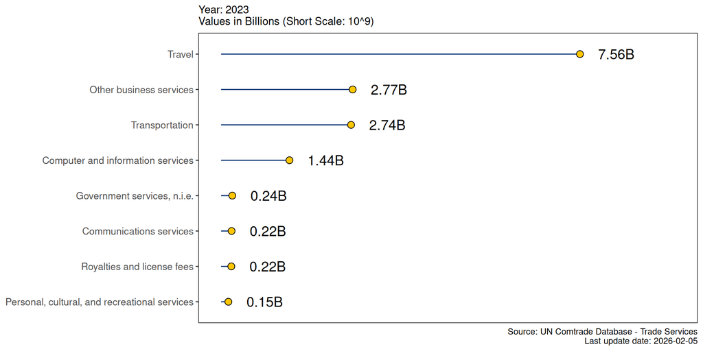

Figure 7: Colombia service exports

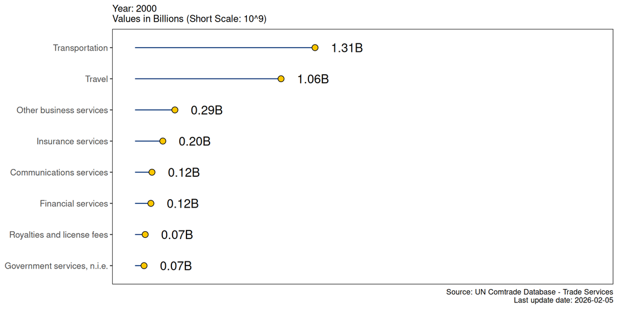

Figure 8: Colombia service imports

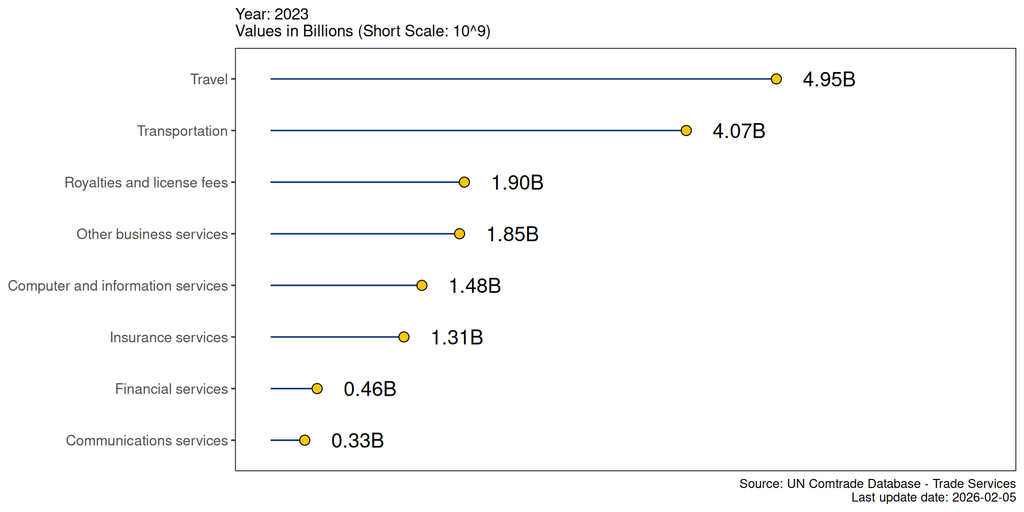

Figure 9: Colombia service imports

# Observatory of Economic Complexity (OEC)

- *“The Observatory of Economic Complexity (OEC) is an online data visualization and distribution platform focused on the geography and dynamics of economic activities”*
- *“The OEC is currently designed and developed by Datawheel, but it began as a research project at MIT’s Collective Learning group (former Macro Connections Group)”*
- Tree map
  - https://oec.world/ > TOOLS > Tree map
    - Country
    - Product
    - Bilateral
- Profiles
  - https://oec.world/ > PROFILES > Countries > Colombia

# Acknowledgments

- To my family that supports me
- To the taxpayers of Colombia and the [**UMNG students**](https://www.umng.edu.co/estudiante) who pay my salary
- To the [**Business Science**](https://www.business-science.io/) and [**R4DS Online Learning**](https://www.rfordatasci.com/) communities where I learn [**R**](https://www.r-project.org/about.html) and [**$\pi$-thon**](https://www.python.org/about/)
- To the [**R Core Team**](https://www.r-project.org/contributors.html), the creators of [**RStudio IDE**](https://posit.co/download/rstudio-desktop/), [**Positron**](https://positron.posit.co/), [**Quarto**](https://quarto.org/) and the authors and maintainers of the packages [**tidyverse**](https://CRAN.R-project.org/package=tidyverse), [**wbstats**](https://CRAN.R-project.org/package=wbstats), [**scales**](https://CRAN.R-project.org/package=scales), [**comtradr**](https://CRAN.R-project.org/package=comtradr) and [**tinytex**](https://CRAN.R-project.org/package=tinytex) for allowing me to access these tools without paying for a license

# References

Cardenas, M. (2020). *Introducción a la Economía Colombiana* (4th ed.). Alfaomega.

Nationen, V., & Kommission, E. (Eds.). (2002). *Manual on statistics of international trade in services*.

Nations, U. (Ed.). (2012). *Manual on Statistics of International Trade in Services 2010: MSITS 2010* (Rev. ed). United Nations.

Ridley, M. (2010). *When ideas have sex*. https://www.ted.com/talks/matt_ridley_when_ideas_have_sex?utm_campaign=tedspread&utm_medium=referral&utm_source=tedcomshare

Simoes, A. J. G., & Hidalgo, C. A. (2011). The economic complexity observatory: An analytical tool for understanding the dynamics of economic development. *Proceedings of the 17th AAAI Conference on Scalable Integration of Analytics and Visualization*, 39–42.